# (Prosper Loan Data)

## by (John Beniamin Kostandy Shenoda)

## Preliminary Wrangling

> A dataset that contains information about loans, its composed of information about the loan amoint, the borrower categeory, the loan period and so on.

|  | LoanOriginalAmount | BorrowerAPR | StatedMonthlyIncome | Term | ProsperRating (Alpha) | EmploymentStatus | MonthlyLoanPayment | Investors | Occupation | CreditGrade | EmploymentStatusDuration | LoanStatus | BorrowerRate |
| --- | --- | --- | --- | --- | --- | --- | --- | --- | --- | --- | --- | --- | --- |
| 0 | 9425 | 0.16516 | 3083.333333 | 36 | NaN | Self-employed | 330.43 | 258 | Other | C | 2.0 | Completed | 0.1580 |
| 1 | 10000 | 0.12016 | 6125.000000 | 36 | A | Employed | 318.93 | 1 | Professional | NaN | 44.0 | Current | 0.0920 |
| 2 | 3001 | 0.28269 | 2083.333333 | 36 | NaN | Not available | 123.32 | 41 | Other | HR | NaN | Completed | 0.2750 |
| 3 | 10000 | 0.12528 | 2875.000000 | 36 | A | Employed | 321.45 | 158 | Skilled Labor | NaN | 113.0 | Current | 0.0974 |
| 4 | 15000 | 0.24614 | 9583.333333 | 36 | D | Employed | 563.97 | 20 | Executive | NaN | 44.0 | Current | 0.2085 |

### What is/are the main feature(s) of interest in your dataset?

> the main features are the amount of money borrowed, the period and categeorising the borrower

### What features in the dataset do you think will help support your investigation into your feature(s) of interest?

> stated monthly income, loan original amount,

## Univariate Exploration

> In this section, investigate distributions of individual variables. If you see unusual points or outliers, take a deeper look to clean things up and prepare yourself to look at relationships between variables.

##### we will start with investigating some variables like loan original amount, monthly income, employment status

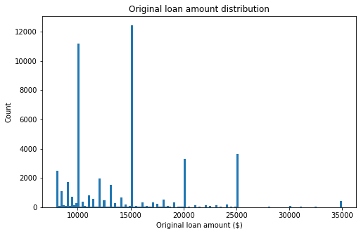

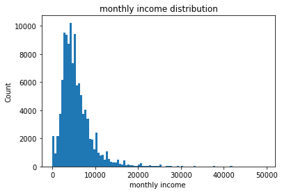

##### we can notice that monthly income distribution is right skewed

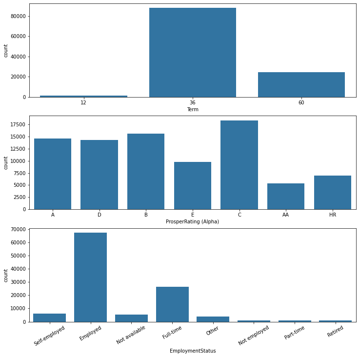

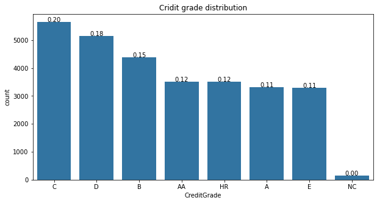

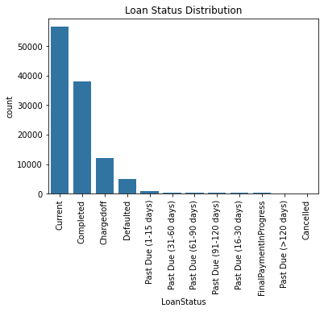

##### we can notice that the most amount of lians are current, which cal=n lead us to further invedstigations

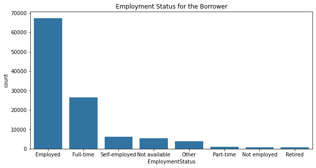

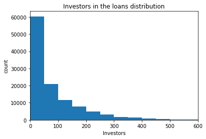

### Discuss the distribution(s) of your variable(s) of interest. Were there any unusual points? Did you need to perform any transformations?

> there is no unusual, its logic that loan increases as the investors increased and as the customer is employed!

### Of the features you investigated, were there any unusual distributions? Did you perform any operations on the data to tidy, adjust, or change the form of the data? If so, why did you do this?

> no there is no need for more operations !

## Bivariate Exploration

> In this section, investigate relationships between pairs of variables in your data. Make sure the variables that you cover here have been introduced in some fashion in the previous section (univariate exploration).

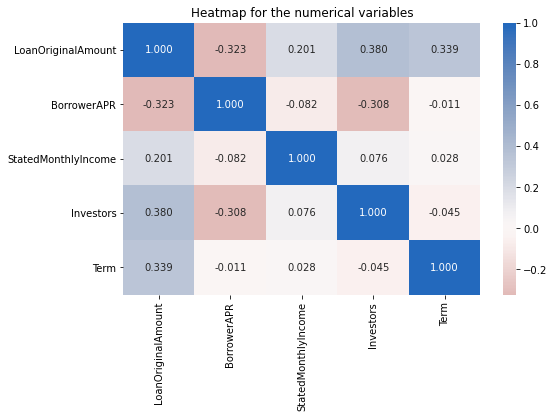

### Did you observe any interesting relationships between the other features (not the main feature(s) of interest)?

> I am astonished about the result that self employed people have less loan as the employed!

## Multivariate Exploration

> Create plots of three or more variables to investigate your data even further. Make sure that your investigations are justified, and follow from your work in the previous sections.

### Were there any interesting or surprising interactions between features?

> data analytics is always interesting as you can read facts through numbers, !

> At the end of your report, make sure that you export the notebook as an html file from the `File > Download as... > HTML` menu. Make sure you keep track of where the exported file goes, so you can put it in the same folder as this notebook for project submission. Also, make sure you remove all of the quote-formatted guide notes like this one before you finish your report!